# Course Review

The Spine of Time Series Analysis

Natasha Kang

Xiamen University, Chow Institute

May, 2026

## Population, Sample, and Inference

Statistical inference rests on a distinction we cannot directly observe:

$$\underbrace{\text{Population (DGP)}}_{\text{what we want to learn}}
\;\xrightarrow{\;\text{sampling}\;}\;
\underbrace{\{Y_1, \ldots, Y_n\}}_{\text{what we observe}}.$$

We see the sample; we want to learn about the population. Two stances — they differ in what *probability itself* refers to:

- **Frequentist.** Probability $=$ long-run frequency in hypothetical repetitions. The parameter $\theta$ is *fixed*; $Y$ is random because re-running the experiment would yield different samples. Inference targets the **sampling distribution** of $\hat\theta(Y_1, \ldots, Y_n)$.
- **Bayesian.** Probability $=$ degree of **belief**. Both $\theta$ and (pre-observation) $Y$ are objects of uncertainty. Bayes’ rule updates a prior $p(\theta)$ into a **posterior**:
  $$p(\theta \mid Y) \;\propto\; p(Y \mid \theta)\, p(\theta).$$

*This course — and most classical econometrics — is frequentist.*

## The Model

A **model** is a **specification** — a claim about a feature (or functional) of the population we want to learn. The feature can be the full distribution, but often it is a more specific quantity:

- *Full distribution:* $P \in \mathcal{P}$.
- *Conditional mean:* $\mathbb{E}_P[Y \mid X] = m(X), \;\; m \in \mathcal{M}$.
- *Moment condition:* $\mathbb{E}_P[\,g(Y, X;\, \theta)\,] = 0$ for some $\theta \in \Theta$.
- *Conditional quantile, spectral density, autocovariance, …*

*Parametric* — feature indexed by a finite-dimensional parameter:

$$\mathcal{M} \;=\; \{\, m_\theta \,:\, \theta \in \Theta \subset \mathbb{R}^p \,\}.$$

*Nonparametric* — feature is an unrestricted function in some (smoothness) class:

$$\mathcal{M} \;=\; \{\, m \,:\, m \in \mathcal{F} \,\}, \qquad \dim(\mathcal{F}) = \infty.$$

*Semiparametric* — a finite-dim feature of interest paired with an infinite-dim nuisance.

## When Is the Model’s Claim Substantive?

For estimation to recover the population feature, two assumptions are at work:

- **Correct specification.** Our claim is *right*: the population feature does take the form we asserted.  
  *Conditional mean example:* $\mathbb{E}_{P_0}[Y \mid X] = m_{\theta_0}(X)$ for some $\theta_0 \in \Theta$.
- **Identification.** Distinct parameters describe distinct features:
  $$\theta_1 \neq \theta_2 \;\Longrightarrow\; m_{\theta_1} \neq m_{\theta_2}.$$

**Under misspecification** — our claim is wrong — the estimator still converges, but to a *pseudo-true* value minimizing some discrepancy from the truth.

*OLS example:* even when $\mathbb{E}[Y \mid X]$ is nonlinear,

$$\hat\beta \;\to\; \beta^{*} \;=\; \arg\min_{\beta} \; \mathbb{E}\bigl[(Y - X'\beta)^2\bigr]$$

— the **best linear predictor** coefficients. The estimand survives even when the conditional-mean claim fails.

> “All models are wrong, some are useful.” — G. E. P. Box

## The Sampling Assumption

Specifies how $\{Y_1, \ldots, Y_n\}$ relates to the population — what *dependence structure* among observations is allowed.

- **iid sampling.** $Y_i \stackrel{\text{iid}}{\sim} P$ — the simplest case; classical cross-sectional statistics.
- **Time series.** A single realization of a stochastic process; observations dependent across $t$.
- **Panel / clustered.** Independence across units, dependence within.
- **Network, spatial.** Dependence structured by a graph or by location.

The sampling assumption determines *which* law of large numbers and *which* central limit theorem are available — and hence what estimation and inference look like.

## The Asymptotic Machinery

**Pointwise** — for a fixed function $g$ or fixed parameter $\theta$:

$$\frac{1}{n}\sum_{i=1}^n g(Y_i) \;\to\; \mathbb{E}[g(Y)] \qquad \text{(LLN — consistency)},$$

$$\sqrt{n}\,(\hat\theta - \theta) \;\Rightarrow\; \mathcal{N}(0,\, V) \qquad \text{(CLT — inference)}.$$

**Uniform** — over a function class $\mathcal{G}$ (**empirical process theory**):

$$\sup_{g \in \mathcal{G}}\,\Bigl|\,\tfrac{1}{n}\textstyle\sum_{i=1}^n g(Y_i) - \mathbb{E}[g(Y)]\,\Bigr| \;\to\; 0 \qquad \text{(Glivenko–Cantelli)},$$

$$\sqrt{n}\,(P_n - P) \;\Rightarrow\; \mathbb{G}_P \;\;\text{on } \mathcal{G} \qquad \text{(Donsker)}.$$

Uniform asymptotics are the machinery for **nonparametric** and **semiparametric** inference.

## How Time Series Specializes Each

| Ingredient | Time-series version |
| --- | --- |
| **Model** | *Parametric:* AR, MA, ARMA, VAR, VECM, SVAR. *Nonparametric:* sample autocovariance, HAC, periodogram. |
| **Sampling assumption** | **One realization** $\{y_1, \ldots, y_T\}$; rely on **stationarity** + **ergodicity**. |
| **Law of large numbers** | **Ergodic theorem** — time averages converge to expectations. |
| **Central limit theorem** | Martingale / mixing CLT; variance $\to$ **long-run variance** $\Omega = \sum_j \gamma(j)$. |

## The Four Blocks

| Block | Units | Driving question |
| --- | --- | --- |
| **A. Stationary univariate** | 1–3 | How do we model and estimate dynamics when the process is stationary? |
| **B. Nonstationarity** | 4 | What changes when there is a unit root? |
| **C. Regression with TS data** | 5 | When can we run OLS with a serially-dependent regressor? |
| **D. Multivariate** | 6–8 | How do we model joint dynamics, long-run links, and structural shocks? |

We will go through each, then step back and look at what threads run *across* them.

# Block A — Stationary Univariate

## Block A — Stationary Univariate (Units 1–3)

**The setup.** A weakly stationary process $\{y_t\}$: constant mean, finite variance, autocovariance depends only on lag.

**The vocabulary.**

- **AR / MA / ARMA** models — built from the lag operator.
- **Wold decomposition**: every stationary process has an MA($\infty$) form.
- **ACF and PACF** as diagnostic fingerprints for model identification.

**The estimation engine.**

- **OLS** for AR models — works because of *ergodicity*, not independence.
- **MLE / QMLE** for MA and ARMA — OLS fails (regressors unobserved).
- Asymptotically normal at the standard $\sqrt{T}$ rate.

## Block A — Key Results

**Model forms.**

- AR($p$): $\;y_t = c + \phi_1 y_{t-1} + \cdots + \phi_p y_{t-p} + \varepsilon_t$
- MA($q$): $\;y_t = \mu + \varepsilon_t + \theta_1 \varepsilon_{t-1} + \cdots + \theta_q \varepsilon_{t-q}$
- ARMA in operator form: $\phi(L)\,y_t = \theta(L)\,\varepsilon_t$.

**Conditions.**

- *Stationarity*: roots of $\phi(z) = 0$ lie outside the unit circle.
- *Invertibility* (MA): roots of $\theta(z) = 0$ lie outside the unit circle.

**Identification fingerprints.**

| Process | ACF | PACF |
| --- | --- | --- |
| AR($p$) | tails off | cuts off at $p$ |
| MA($q$) | cuts off at $q$ | tails off |
| ARMA($p,q$) | tails off | tails off |

**Limit.** $\sqrt{T}(\hat\theta - \theta) \Rightarrow \mathcal{N}(0,\,V)$. Under correct specification, classical $\sigma^2 Q^{-1}$ (OLS) or inverse Fisher information (MLE) suffices — no HAC.

# Block B — Nonstationarity

## Block B — Nonstationarity (Unit 4)

**The setup.** Stationarity fails — the variance grows, shocks accumulate. A *unit root*.

**The vocabulary.**

- **I(d)**: order of integration; differencing as a path back to stationarity.
- **Random walk**, **ARIMA(p, d, q)** as the workhorse model.
- Trend-stationary vs. difference-stationary — the right transformation matters.

**The asymptotic toolkit changes.**

- $\hat\rho$ converges at rate $T$, not $\sqrt{T}$.
- Limit distribution involves **Brownian motion** — the **Dickey–Fuller** distribution.
- ADF test, Dickey–Pantula for multiple unit roots.

**Forecasting:** ARIMA point forecasts, prediction intervals widening with horizon.

## Block B — Key Results: Unit Root Tests

**Dickey–Fuller regressions** (three variants — no constant, with constant, with constant and trend):

$$\Delta y_t = \rho\, y_{t-1} + \varepsilon_t,
\quad
\Delta y_t = c + \rho\, y_{t-1} + \varepsilon_t,
\quad
\Delta y_t = c + \delta t + \rho\, y_{t-1} + \varepsilon_t.$$

Test $H_0:\rho = 0$ (unit root) against $H_1:\rho < 0$ using **non-standard DF critical values**, which differ across the three variants.

**ADF augmentation.** Add $\sum_{j=1}^{k} \gamma_j \Delta y_{t-j}$ to absorb residual serial correlation; the $t$-statistic on $\hat\rho$ keeps the same DF limit.

## Block B — Key Results: Asymptotics and Forecasting

**Rate-$T$ convergence under a unit root.** For AR(1) with $\rho = 1$,

$$T(\hat\rho - 1) \;\Rightarrow\; \frac{\tfrac{1}{2}\bigl(W(1)^2 - 1\bigr)}{\int_0^1 W(r)^2\,dr},$$

where $W$ is standard Brownian motion. Rate is $T$, not $\sqrt{T}$; the limit is a functional of $W$, not Normal.

**ARIMA($p, d, q$).** Apply ARMA to $\Delta^d y_t$. For I(1), prediction-interval half-width grows like $\sqrt{h}$ at horizon $h$ — uncertainty accumulates with the random walk, unlike the bounded intervals of stationary forecasts.

# Block C — Regression with Time Series

## Block C — Regression with Time Series (Unit 5)

**The setup.** $y_t = x_t'\beta + u_t$ with $\{x_t, u_t\}$ **stationary and ergodic**, but serially dependent.

**Two exogeneity conditions.**

- *Strict exogeneity* $\mathbb{E}[u_t \mid x_1, \ldots, x_T] = 0$ — needed for OLS *unbiasedness*. Fails whenever $x_t$ contains a lagged dependent variable.
- *Orthogonality (weak exogeneity)* $\mathbb{E}[x_t u_t] = 0$ — needed for OLS *consistency*. Holds even with lagged $y_t$ on the right.

**Consistency** then follows: by the ergodic theorem,
$$T^{-1}\sum x_t x_t' \to Q, \qquad T^{-1}\sum x_t u_t \to 0, \qquad \hat\beta_{\text{OLS}} \overset{p}{\to} \beta.$$

**Inference: classical formulas break.**

- $\mathrm{Var}(\sqrt{T}\,\bar z) \to$ **long-run variance** $\Omega = \sum_j \gamma_z(j)$, *not* $\sigma^2$.
- **HAC (Newey–West)** estimator of $\Omega$.

**Dynamic regression payoff.** ADL → impulse response; long-run multiplier $= \beta(1)/\phi(1)$.

## Block C — Key Results

**Asymptotic distribution** of OLS under stationary, ergodic $\{x_t, u_t\}$:

$$\sqrt{T}\,(\hat\beta - \beta) \;\Rightarrow\; \mathcal{N}\!\left(0,\; Q^{-1}\,\Omega\, Q^{-1}\right),
\qquad
Q = \mathbb{E}[x_t x_t'].$$

**Long-run variance.** With $z_t = x_t u_t$,

$$\Omega \;=\; \sum_{j=-\infty}^{\infty} \mathbb{E}[z_t z_{t-j}']
\;=\; \gamma_z(0) + \sum_{j=1}^{\infty} \bigl(\gamma_z(j) + \gamma_z(j)'\bigr).$$

Classical formulas plug in $\sigma^2 Q^{-1}$, which is wrong whenever $\gamma_z(j) \neq 0$ for some $j \neq 0$.

**HAC (Newey–West).** Bartlett kernel with bandwidth $m$:

$$\hat\Omega \;=\; \hat\gamma_0 + \sum_{j=1}^{m}\!\Bigl(1 - \tfrac{j}{m+1}\Bigr)\bigl(\hat\gamma_j + \hat\gamma_j'\bigr),
\qquad m \sim T^{1/3}.$$

**ADL($p,q$) long-run multiplier.** With $\phi(L)\, y_t = \alpha + \beta(L)\, x_t + u_t$,

$$\text{LRM} \;=\; \frac{\beta(1)}{\phi(1)} \;=\; \frac{\beta_0 + \beta_1 + \cdots + \beta_q}{1 - \phi_1 - \cdots - \phi_p}.$$

# Block D — Multivariate

## Block D₁ — Spurious Regression and Cointegration (Unit 6)

**The trap.** Regressing one I(1) series on another gives high $R^2$ and significant $t$-statistics even when the series are independent.

**The escape.** Two I(1) series are **cointegrated** if some linear combination $\beta'x_t$ is I(0) — they share a common stochastic trend.

**Tools.**

- **Engle–Granger** two-step: estimate $\beta$ in levels, test the residual for a unit root.
- **Error-correction model (ECM):** short-run dynamics + adjustment to the long-run equilibrium.

## Block D₁ — Key Results

**Engle–Granger two-step.**

1. *Cointegrating regression.* OLS on $y_t = \alpha + \beta\, x_t + u_t$ in levels. Under cointegration, $\hat\beta$ is **super-consistent**: $T(\hat\beta - \beta) = O_p(1)$, mixed-Normal limit.
2. *Residual unit-root test.* Apply ADF to $\hat u_t$ using Engle–Granger critical values — shifted left of standard ADF because estimating $\beta$ pre-shrinks the residual.

**Error-correction model.** Let $z_t = y_t - \beta x_t$ be the (stationary) cointegrating relation:

$$\Delta y_t \;=\; \alpha\, z_{t-1} \;+\; \sum_j \gamma_j \,\Delta x_{t-j} \;+\; \sum_j \delta_j \,\Delta y_{t-j} \;+\; \varepsilon_t.$$

Sign and magnitude of $\alpha$: $\alpha < 0$ pulls $y_t$ back toward equilibrium $z_t = 0$; $|\alpha|$ is the speed of adjustment.

**Granger representation theorem.** Cointegration $\iff$ a valid ECM representation exists. Levels regression + ECM is one decomposition; VECM (Block D₂) is its multivariate counterpart.

## Block D₂ — VAR, VECM, Johansen (Unit 7)

**Lifting Block A to vectors.**

- **VAR($p$)**: $x_t = c + A_1 x_{t-1} + \cdots + A_p x_{t-p} + u_t$.
- **Companion form** → stability via eigenvalues → MA($\infty$) representation.
- Forecasting and **forecast-error variance** generalize ARIMA forecasting.

**Lifting Block D₁ to vectors.**

- If $x_t$ is I(1) but cointegrated, the VAR in levels has reduced rank: $\Pi = \alpha\beta'$.
- The differenced + level form is a **VECM**.
- **Johansen** rank tests (trace, max-eigenvalue) — non-standard distributions.

## Block D₂ — Key Results: VAR and VECM

**VAR($p$) stability.** Roots of $\det\bigl(I_k - A_1 z - \cdots - A_p z^p\bigr) = 0$ lie outside the unit circle. Equivalently, eigenvalues of the companion matrix lie inside the unit circle.

**MA($\infty$) representation.** $x_t = \mu + \sum_{j=0}^{\infty} \Psi_j\, u_{t-j}$, with $\Psi(L) = A(L)^{-1}$.

**Reduction to VECM.** Subtract $x_{t-1}$ and collect:

$$\Delta x_t \;=\; \Pi\, x_{t-1} \;+\; \sum_{j=1}^{p-1} \Gamma_j\, \Delta x_{t-j} \;+\; u_t,
\qquad
\Pi = -\bigl(I - A_1 - \cdots - A_p\bigr).$$

Cointegrated $\iff 0 < \mathrm{rank}(\Pi) = r < k$, with $\Pi = \alpha\,\beta'$, where $\alpha,\beta$ are each $k\times r$.

## Block D₂ — Key Results: Johansen Test

From canonical-correlation eigenvalues $\hat\lambda_1 \ge \cdots \ge \hat\lambda_k$ of a reduced-rank regression of $\Delta x_t$ on $x_{t-1}$ (after partialling out lagged differences):

$$\mathrm{LR}_{\text{trace}}(r) \;=\; -T \sum_{i=r+1}^{k} \log(1 - \hat\lambda_i),$$

$$\mathrm{LR}_{\max}(r) \;=\; -T \log(1 - \hat\lambda_{r+1}).$$

Both have **non-standard limits** — tabulated against Brownian-motion functionals indexed by $k - r$ and the deterministic specification.

## What Johansen Actually Identifies

**The data identifies a *space*, not specific vectors.**

- Cointegrating rank $r$: number of independent stationary linear combinations.
- $\hat\beta$ (estimated $k \times r$ matrix): a *basis* for the $r$-dimensional cointegrating space.

**Rotation invariance.** For any invertible $r \times r$ matrix $H$,
$$(\alpha,\,\beta)\quad\text{and}\quad(\alpha H^{-1},\,\beta H)$$
give the same $\Pi = \alpha\beta'$. The data cannot distinguish them.

**Theory chooses the basis.** *Example:* stock prices, dividends, earnings $(p_t, d_t, e_t)$, all $I(1)$, $r = 2$:

- *Theoretically named:* $\{(1,-1,0),\,(0,1,-1)\}$ → log dividend yield + log payout ratio.
- *Equally valid mathematically:* $\{(2,-3,1),\,(1,1,-2)\}$ → no economic name.

Same cointegrating space, same $\Pi$. Data picks the space; only theory picks the basis whose vectors map to economically interpretable relations.

**Orthogonal complement.** Dimension $k - r$ = number of *common stochastic trends* driving the system.

## Block D₃ — Structural VARs (Unit 8)

**The new question.** What is the effect of a *structural* shock — e.g., an unexpected monetary tightening?

**The new obstacle.** Reduced-form innovations $u_t$ are *mixtures* of structural shocks $\varepsilon_t = B^{-1} u_t$. The data alone cannot recover $B$.

**Identification = restrictions on $B$.**

- **Recursive (Cholesky)**: triangular ordering by speed of response.
- **Long-run (Blanchard–Quah)**: restrictions on cumulative IRFs.
- **Sign restrictions**, **proxy SVAR / external instruments**.

Outputs: **structural IRFs**, **FEVD**, with bootstrapped error bands.

## Block D₃ — Key Results: Reduced to Structural

Let $u_t = B\,\varepsilon_t$ with $\mathrm{Var}(\varepsilon_t) = I_k$. The covariance identity

$$\Sigma_u \;=\; B B'$$

gives $k(k+1)/2$ equations for the $k^2$ unknowns in $B$. Identification requires $k(k-1)/2$ additional restrictions.

**Structural IRF and FEVD.** With reduced-form MA coefficients $\Psi_h$, set $\Theta_h = \Psi_h B$. The $h$-step FEVD share of variable $i$ from shock $j$ is

$$\omega_{ij}(h) \;=\; \frac{\sum_{s=0}^{h-1}(e_i'\,\Theta_s\, e_j)^2}{\sum_{s=0}^{h-1} e_i'\,\Theta_s\,\Theta_s'\, e_i},
\qquad \sum_{j=1}^k \omega_{ij}(h) = 1.$$

## Block D₃ — Key Results: Identification Strategies

- **Cholesky (recursive):** $B$ lower-triangular — fast-to-slow ordering on impact.
- **Blanchard–Quah:** $\sum_{h=0}^{\infty} \Theta_h$ lower-triangular — long-run zero restrictions on cumulative IRFs.
- **Sign restrictions:** set-identification via sign patterns on IRFs implied by theory.
- **Proxy SVAR / external instrument:** instrument $m_t$ correlated with one structural shock, uncorrelated with the others.

# Through-Lines

## Through-Line 1 — Stationarity Enables Estimation

The same logical chain recurs across the course:

$$\text{stationarity} \;+\; \text{ergodicity}
\;\Longrightarrow\;
\text{time averages} \to \text{population moments}
\;\Longrightarrow\;
\hat\theta \to \theta.$$

- Unit 3: $\hat\rho \to \rho$ for AR(1).
- Unit 5: $\hat\beta \to \beta$ in TS regression.
- Unit 7: equation-by-equation OLS in stationary VAR.

**Asymptotic normality** comes from a CLT applied to a *martingale-difference* numerator $T^{-1/2}\sum x_t u_t$.

When stationarity fails (Unit 4), the entire chain breaks — and the limit changes form.

## Through-Line 2 — Standard vs. Non-Standard Asymptotics

**For estimators**, the rate at which $\hat\theta - \theta$ shrinks depends on whether the underlying process is stationary:

| Setting | Rate | Limit |
| --- | --- | --- |
| Stationary OLS / MLE (A, C) | $\sqrt{T}$ | Normal |
| Stationary VAR (D₂) | $\sqrt{T}$ | Normal |
| OLS under unit root (B) | $T$ | Dickey–Fuller (functional of Brownian motion) |
| Cointegrating vector $\hat\beta$ (D₁) | $T$ | Mixed normal — *super-consistent* |

**Johansen rank test (D₂)** is a *test statistic*, not an estimator — the $T$ scaling is built into the construction $\mathrm{trace} = -T\sum \log(1-\hat\lambda_i)$, so the statistic has a non-degenerate limit under the null (trace / max-eigenvalue distributions) without further normalization.

**Rule of thumb.** Nonstationary regressors → non-standard limits. But pre-tested I(0) combinations (residual of a cointegrating regression, $\Delta x_t$ in a VECM) recover standard inference.

## Through-Line 3 — Representation Duality

**Same process, multiple lenses.**

| Primary form | Dual form | When the dual is useful |
| --- | --- | --- |
| AR($p$) | MA($\infty$) | Reading dynamic effects (IRF) |
| VAR levels | VECM | Imposing cointegration rank |
| Reduced-form VAR | Structural VAR | Causal interpretation of shocks |

The data identify the **primary form**.

The **dual form** requires either an algebraic move (Wold decomposition, companion form) or **identifying restrictions** (cointegration rank, $B^{-1}$ structure).

This is the difference between *fitting the data* and *interpreting it*.

## Through-Line 4 — The Forecasting Thread

The same object — **forecast-error variance** — is sliced under progressively stronger assumptions.

| Unit | Object | What is assumed |
| --- | --- | --- |
| 1 | Linear projection $\hat y_{t+h \mid t}$ | Stationarity |
| 4 | ARIMA prediction interval | A specified ARIMA model |
| 7 | VAR forecast and $\Psi_j \Sigma_u \Psi_j'$ FEV | A specified reduced-form VAR |
| 8 | **FEVD** by structural shock | An identification scheme |

The progression is not “more accurate” — it is “more interpretable.” Each layer answers a question the prior layer could not.

# Practice Questions

## Practice 1

Two researchers fit the same regression $y_t = \beta_0 + \beta_1 x_t + u_t$. They report the same $\hat\beta_1 = 0.5$ but report very different standard errors: Researcher A (classical OLS) reports $0.08$; Researcher B (HAC) reports $0.18$.

1. Both target the same population object $V = Q^{-1}\Omega Q^{-1}$. Trace the disagreement back to a difference in what each implicitly assumes about $\Omega$.
2. The classical formula amounts to $\Omega = \sigma^2 Q$. Name the **two** distinct properties of $\{x_t u_t\}$ that this equality requires. Under serial correlation alone (but homoskedasticity), which one fails?
3. A colleague suggests using White’s heteroskedasticity-robust standard errors instead of HAC. Under what residual property would White’s HC *not* be enough? Be precise about what HC fixes and what it does not.

## Practice 2

$(p_t, q_t)$ are I(1) and cointegrated with relation $z_t = p_t - \beta q_t$, $\beta > 0$. Bivariate ECM:

$$\Delta p_t = \alpha_p\, z_{t-1} + (\text{lags}) + \varepsilon_{p,t}, \qquad
\Delta q_t = \alpha_q\, z_{t-1} + (\text{lags}) + \varepsilon_{q,t}.$$

1. Suppose $z_{t-1} > 0$ ($p$ is above its long-run level). Express $\Delta z_t$ in terms of $z_{t-1}$ and $(\alpha_p, \alpha_q)$. What condition on the *combination* $\alpha_p - \beta\alpha_q$ is needed for the system to pull $z_t$ back toward $0$?
2. Suppose institutional friction prevents $q_t$ from responding to past disequilibrium, so $\alpha_q = 0$. What does this force on $\alpha_p$? Which series then bears *all* of the adjustment burden?
3. Granger representation: cointegration $\Leftrightarrow$ at least one of $(\alpha_p, \alpha_q)$ is nonzero. If we instead find $\hat\alpha_p \approx \hat\alpha_q \approx 0$ in the data, what does this tell us about the original cointegration claim?

## Practice 3

Four-variable system $z_t = (c_t,\, y_t,\, w_t,\, m_t)'$, each I(1) — log consumption, income, wealth, and nominal money. Theory implies two cointegrating relations:

1. Consumption–income ratio $c_t - y_t$ is stationary.
2. Money–income ratio $m_t - y_t$ is stationary.
1. Write $\beta$ ($4 \times 2$). State $\mathrm{rank}(\Pi)$ and the number of common stochastic trends.
2. Under these two restrictions, which of the following pairs are *also* cointegrated? Justify each by exhibiting (or ruling out) a linear combination of $\beta$’s columns:
- $c_t$ and $m_t$
- $c_t$ and $w_t$
- $y_t$ and $m_t$
3. Asymptotically, $\hat\beta$ from Johansen converges to *some* basis of the cointegrating space, generally not the basis from (a). What does the data uniquely identify, and what extra input is needed to interpret a column of $\hat\beta$ as a specific economic relation?

## Practice 4

A 3-variable monetary SVAR with $x_t = (y_t, \pi_t, i_t)'$.

1. The analyst orders $(y_t, \pi_t, i_t)$ with policy rate last and uses Cholesky. State the *timing* assumption this places on the monetary-policy shock $\varepsilon_t^{mp}$. When is this defensible?
2. Suppose policy moves are partially *anticipated* — the central bank announces in quarter $t-1$ a tightening that takes effect in $t$. By the time $\Delta i_t$ appears, $y_t$ and $\pi_t$ have already absorbed the news. Why does this break Cholesky identification — and why does the problem extend to *any* identification scheme that pins down $B$ from $\Sigma_u$ alone (sign restrictions, long-run restrictions, etc.)?
3. Proxy SVAR uses an external instrument $z_t$ correlated with $\varepsilon_t^{mp}$ and uncorrelated with the other structural shocks. Why does $z_t$ constructed from *high-frequency* (intraday) interest-rate surprises around FOMC announcements address the anticipation concern, while a *quarterly* narrative dummy for “tightening cycles” might not?

# A New Lens — Spectral Analysis

*Not on the final — included as a different way of seeing what we have already studied.*

## Why a Frequency-Domain View?

The time-domain language describes dynamics *lag by lag*. The frequency-domain language describes them *cycle by cycle*. The two are mathematically equivalent — but they make different things easy to see.

**What spectral analysis buys you.**

- **Cyclical structure becomes visible.** Business-cycle, seasonal, and high-frequency components live at distinct $\omega$; one plot separates them.
- **Variance decomposition by frequency band.** $\int_{\omega_1}^{\omega_2} f(\omega)\,d\omega$ is the variance contributed by cycles of period $\in [2\pi/\omega_2,\, 2\pi/\omega_1]$.
- **Filters become multiplication.** Applying $a(L)$ multiplies the spectrum by $|a(e^{-i\omega})|^2$. Filter design (HP, band-pass, differencing) is transparent in this representation.
- **Direct link to long-run variance.** The HAC object from Block C satisfies $\Omega = 2\pi f(0)$ — the spectrum at frequency zero.
- **Asymptotic independence.** Periodogram ordinates at distinct Fourier frequencies are asymptotically independent — a property that has no counterpart in the time domain.

## Spectral Analysis I — Two Equivalent Views

A stationary process can be described in two equivalent ways:

- **Time domain**: the autocovariance function $\gamma(h)$.
- **Frequency domain**: the **spectral density** $f(\omega)$ — how variance is distributed across cycles of frequency $\omega$.

**Wiener–Khinchin theorem.** $\gamma$ and $f$ are a Fourier transform pair:

$$f(\omega) \;=\; \frac{1}{2\pi}\sum_{h=-\infty}^{\infty} \gamma(h)\, e^{-i\omega h},
\qquad
\gamma(h) \;=\; \int_{-\pi}^{\pi} f(\omega)\, e^{i\omega h}\,d\omega.$$

**Variance decomposition by frequency.**

$$\gamma(0) \;=\; \mathrm{Var}(y_t) \;=\; \int_{-\pi}^{\pi} f(\omega)\, d\omega.$$

The area under $f$ between two frequencies is the variance contributed by cycles in that band.

## Canonical Spectra

Four illustrations of how time-domain dynamics map to frequency-domain shape.

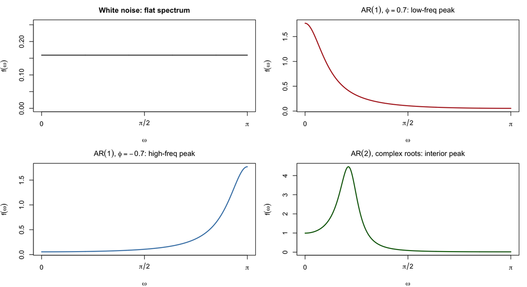

- **White noise**: flat — equal power at every frequency.
- **AR(1), $\phi>0$**: peak at $\omega = 0$ (“red noise” — persistence concentrates power at low frequencies).
- **AR(1), $\phi<0$**: peak at $\omega = \pi$ (“blue noise” — sign-flipping oscillation).
- **AR(2), complex roots**: intrinsic cycle — peak at an interior $\omega^\star \in (0, \pi)$, period $2\pi/\omega^\star$.

## Sample Side and Filters

**Periodogram.** The sample analogue of $f(\omega)$:

$$I(\omega_j) \;=\; \frac{1}{2\pi T}\,\Bigl|\,\sum_{t=1}^{T} y_t\, e^{-i\omega_j t}\,\Bigr|^2,
\qquad \omega_j = \frac{2\pi j}{T}.$$

Unbiased but **not consistent** — variance does not vanish as $T \to \infty$. Smoothing across nearby Fourier frequencies (kernel-weighted average) yields a consistent estimator.

**Filters in the frequency domain.** A filter $a(L)$ acts on the spectrum multiplicatively:

$$f_{a(L) y}(\omega) \;=\; \bigl|\,a(e^{-i\omega})\,\bigr|^2\, f_y(\omega).$$

- **Differencing** $(1 - L)$: $|1 - e^{-i\omega}|^2 = 2 - 2\cos\omega$ — zero at $\omega = 0$, so trends are removed.
- **Summing / centered moving average**: damps high frequencies — smoothing.
- **Baxter–King**: explicit band-pass filter designed in the frequency domain. (HP is a time-domain penalized smoother — its frequency response is only derived after the fact, not the design principle.)